# Quick start to Harmony

https://portals.broadinstitute.org/harmony/articles/quickstart.html

```r
library(harmony)
library(ggplot2)
```

```r
colors_use <- c(`jurkat` = '#810F7C', `t293` = '#D09E2D',`half` = '#006D2C')
```

```r
do_scatter <- function(umap_use, meta_data, label_name, no_guides = TRUE,
                       do_labels = TRUE, nice_names,
                       palette_use = colors_use,
                       pt_size = 4, point_size = .5, base_size = 12,
                       do_points = TRUE, do_density = FALSE, h = 6, w = 8) {
    umap_use <- umap_use[, 1:2]
    colnames(umap_use) <- c('X1', 'X2')
    plt_df <- umap_use %>% data.frame() %>%
        cbind(meta_data) %>%
        dplyr::sample_frac(1L)
    plt_df$given_name <- plt_df[[label_name]]

    if (!missing(nice_names)) {
        plt_df %<>%
            dplyr::inner_join(nice_names, by = "given_name") %>%
            subset(nice_name != "" & !is.na(nice_name))

        plt_df[[label_name]] <- plt_df$nice_name
    }

    plt <- plt_df %>%
        ggplot(aes_string("X1", "X2", col = label_name, fill = label_name)) +
        theme_test(base_size = base_size) +
        theme(panel.background = element_rect(fill = NA, color = "black")) +
        guides(color = guide_legend(override.aes = list(stroke = 1, alpha = 1,
                                                        shape = 16, size = 4)),
               alpha = FALSE) +
        scale_color_manual(values = palette_use) +
        scale_fill_manual(values = palette_use) +
        theme(plot.title = element_text(hjust = .5)) +
        labs(x = "PC 1", y = "PC 2")

    if (do_points)
        plt <- plt + geom_point(shape = '.')
    if (do_density)
        plt <- plt + geom_density_2d()


    if (no_guides)
        plt <- plt + guides(col = FALSE, fill = FALSE, alpha = FALSE)

    if (do_labels) {
        data_labels <- plt_df %>%
            dplyr::group_by_(label_name) %>%
            dplyr::summarise(X1 = mean(X1), X2 = mean(X2)) %>%
            dplyr::ungroup()

        plt <- plt + geom_label(data = data_labels, label.size = NA,
                        aes_string(label = label_name),
                        color = "white", size = pt_size, alpha = 1,
                        segment.size = 0) +
                guides(col = FALSE, fill = FALSE)
    }

    return(plt)
}
```

```r
data(cell_lines)
V <- cell_lines$scaled_pcs
meta_data <- cell_lines$meta_data
```

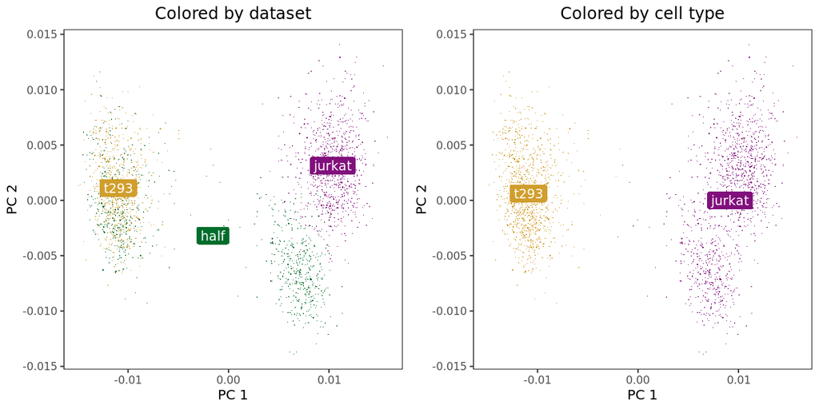

```r
options(repr.plot.width = 10, repr.plot.height = 5)
p1 <- do_scatter(V, meta_data, 'dataset')   + labs(title = 'Colored by dataset')
p2 <- do_scatter(V, meta_data, 'cell_type') + labs(title = 'Colored by cell type')
cowplot::plot_grid(p1, p2)
```

Harmonyを実行して、dataset-of-originの影響を除去してみましょう。デフォルトでは、Harmonyは正規化された遺伝子発現行列を受け入れ、PCAを実行します。ここではすでにPCAを行っているので、`do_pca=FALSE`と指定しています。行列 `harmony_embeddings`は、Harmonyが補正したPCA行列です。

```r
harmony_embeddings <- harmony::HarmonyMatrix(
    V, meta_data, 'dataset', do_pca = FALSE, verbose=FALSE
)
```

[output not shown]

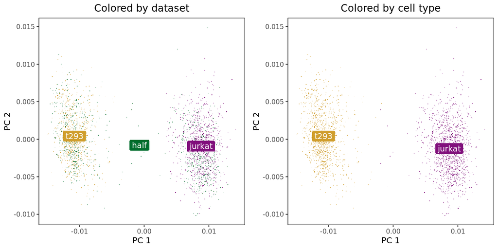

```r
p1 <- do_scatter(harmony_embeddings, meta_data, 'dataset')   + labs(title = 'Colored by dataset')
p2 <- do_scatter(harmony_embeddings, meta_data, 'cell_type') + labs(title = 'Colored by cell type')
cowplot::plot_grid(p1, p2, nrow = 1)
```

HarmonyはSeurat、MUDAN、scranなどのいくつかのパッケージで実行することができます。 これらのビネットについては[こちら](https://portals.broadinstitute.org/harmony/articles/software.broadinstitute.org/harmony)をご覧ください。

Harmonyを実行する最も一般的な方法は、主成分分析（PCA)などの低次元上での実行です。 低次元エンベッディングを使用する場合は、`do_pca = FALSE`に設定してください。Harmonyパッケージには、小さなscRNA-seqデータセットが含まれています。

```r
library(harmony)

data(cell_lines)
cell_lines$meta_data[1:5,]
```

A tibble: 5 × 5

| cell_id <chr> | dataset <chr> | nGene <int> | percent_mito <dbl> | cell_type <chr> |
| --- | --- | --- | --- | --- |
| half_GTACGAACCACCAA | half | 1508 | 0.01477707 | jurkat |
| t293_AGGTCATGCACTTT | t293 | 4009 | 0.02321219 | t293 |
| half_ATAGTTGACTTCTA | half | 3545 | 0.01526671 | jurkat |
| half_GAGCGGCTTGCTTT | half | 2450 | 0.01703195 | jurkat |
| jurkat_CTGATACTCCGTAA | jurkat | 2388 | 0.06014961 | jurkat |

```r
cell_lines$scaled_pcs[1:5,1:5]
```

A data.table: 5 × 5

|  | X1 <dbl> | X2 <dbl> | X3 <dbl> | X4 <dbl> | X5 <dbl> |
| --- | --- | --- | --- | --- | --- |
| 1 | 0.002806741 | -0.0014502980 | -0.0063901369 | 0.0002824677 | 0.001444069 |
| 2 | -0.011669691 | 0.0008773044 | 0.0008972694 | 0.0013239566 | -0.003291763 |
| 3 | 0.009334467 | -0.0069718865 | -0.0025989384 | 0.0018824674 | -0.003803677 |
| 4 | 0.006339979 | -0.0025175931 | -0.0043900882 | 0.0002737979 | -0.002497476 |
| 5 | 0.008545583 | 0.0070866873 | -0.0022541011 | 0.0016793801 | 0.004554607 |

```r
harmonized_pcs <- HarmonyMatrix(
  data_mat  = cell_lines$scaled_pcs,
  meta_data = cell_lines$meta_data,
  vars_use  = "dataset",
  do_pca    = FALSE
)

harmonized_pcs[1:5,1:5]
```

```
Harmony 1/10

Harmony 2/10

Harmony 3/10

Harmony 4/10

Harmony 5/10

Harmony converged after 5 iterations
```

A matrix: 5 × 5 of type dbl

| X1 | X2 | X3 | X4 | X5 |
| --- | --- | --- | --- | --- |
| 0.004363511 | 0.0023198832 | -4.193316e-03 | 0.0005559784 | 0.001554868 |
| -0.011639932 | 0.0001900404 | 3.183030e-04 | 0.0010882630 | -0.003430608 |
| 0.010957944 | -0.0024964250 | -7.373746e-05 | 0.0019881140 | -0.003585290 |
| 0.008197921 | 0.0018902147 | -1.537939e-03 | 0.0006281093 | -0.002224531 |
| 0.006916569 | 0.0032019137 | -4.594682e-03 | 0.0013515242 | 0.004468109 |

また、total UMIで正規化されたsparse matrixにHarmonyを実行することもできます。 `HarmonyMatrix()` 関数は、マトリックスデータのスケーリング、PCAの実行、Harmonyの統合アルゴリズムの実行を行います。

```r
library(harmony)
my_harmony_embeddings <- HarmonyMatrix(
  data_mat  = normalized_counts,
  meta_data = meta_data,
  vars_use  = "dataset"
)
```

[output not shown]

## Harmony with two or more covariates

Harmony can integrate over multiple covariates. To do this, specify a vector covariates to integrate.

```r
harmonized_pcs <- HarmonyMatrix(
  data_mat  = scaled_pcs,
  meta_data = meta_data,
  vars_use  = c("dataset", "donor", "batch_id"), # multiple covariates
  do_pca    = FALSE
)
```

## Seurat V3 Interface

http://htmlpreview.github.io/?https://github.com/immunogenomics/harmony/blob/master/docs/SeuratV3.html

```r
library(Seurat)
library(cowplot)
library(harmony)
```

```r
load('pbmc_stim.RData')
```

### Initialize Seurat Object

Harmonyを実行する前に、Seuratオブジェクトを作成し、PCAを介して標準のパイプラインに従ってください。

重要な違い：Seurat統合チュートリアルでは、データセットごとにSeuratオブジェクトを定義する必要があります。Harmonyの統合では、すべてのセルで1つのSeuratオブジェクトだけを作成します。

```r
pbmc <- CreateSeuratObject(counts = cbind(stim.sparse, ctrl.sparse), project = "PBMC", min.cells = 5) %>%
    Seurat::NormalizeData(verbose = FALSE) %>%
    FindVariableFeatures(selection.method = "vst", nfeatures = 2000) %>%
    ScaleData(verbose = FALSE) %>%
    RunPCA(pc.genes = pbmc@var.genes, npcs = 20, verbose = FALSE)
```

データセットIDがオブジェクトのメタデータにあることを確認してください。ここでは、変数stimでデータセットを定義しています。

```r
pbmc@meta.data$stim <- c(rep("STIM", ncol(stim.sparse)), rep("CTRL", ncol(ctrl.sparse)))
```

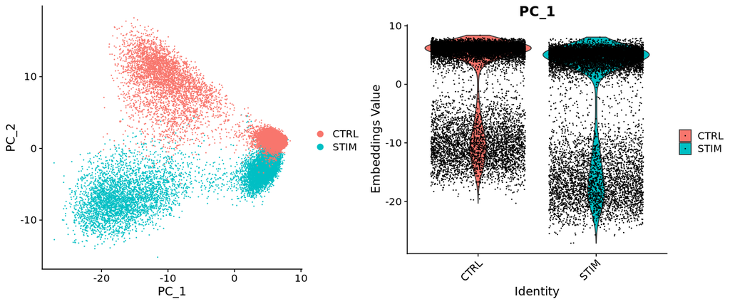

```r
options(repr.plot.height = 5, repr.plot.width = 12)
p1 <- DimPlot(object = pbmc, reduction = "pca", pt.size = .1, group.by = "stim") # , do.return = TRUE
p2 <- VlnPlot(object = pbmc, features = "PC_1", group.by = "stim", pt.size = .1) # , do.return = TRUE
plot_grid(p1,p2)
```

### Run Harmony

Harmonyを実行する最も簡単な方法は、Seuratオブジェクトを渡して、統合する変数を指定することです。 `RunHarmony`は、修正された調和座標で更新されたSeuratオブジェクトを返します。 `plot_convergence`をTRUEに設定して、Harmony 目的関数が各ラウンドでより良くなるようにしましょう

```
Harmony 1/10

Harmony 2/10

Harmony 3/10

Harmony 4/10

Harmony 5/10

Harmony 6/10

Harmony 7/10

Harmony 8/10

Harmony converged after 8 iterations

Warning message:
“Invalid name supplied, making object name syntactically valid. New object name is Seurat..ProjectDim.RNA.harmony; see ?make.names for more details on syntax validity”
```

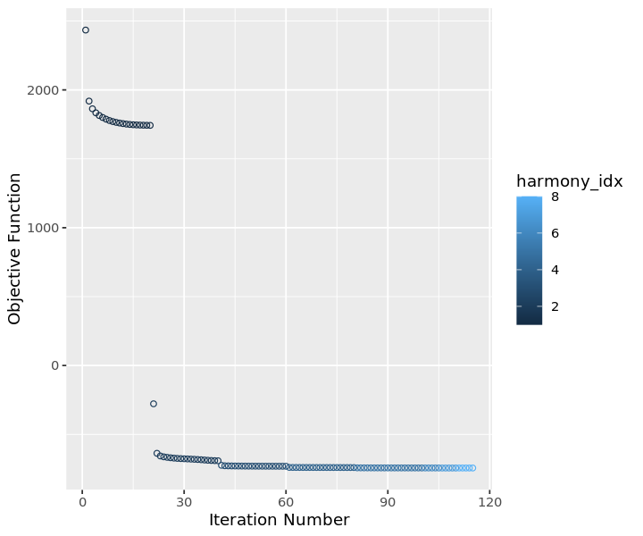

```r
options(repr.plot.height = 5, repr.plot.width = 6)
pbmc <- pbmc %>% RunHarmony("stim", plot_convergence = TRUE)
```

```r
# To directly access the new Harmony embeddings, use the Embeddings command.

harmony_embeddings <- Embeddings(pbmc, 'harmony')
harmony_embeddings[1:5, 1:5]
```

A matrix: 5 × 5 of type dbl

|  | harmony_1 | harmony_2 | harmony_3 | harmony_4 | harmony_5 |
| --- | --- | --- | --- | --- | --- |
| AAACATACCAAGCT-1 | 3.958360 | -0.9863755 | -4.9353823 | -6.118284 | 1.8359485 |
| AAACATACCCCTAC-1 | -1.633636 | -0.9334434 | 7.7282070 | -8.841319 | 2.9975076 |
| AAACATACCCGTAA-1 | 5.798993 | 1.6573032 | 0.6686383 | 1.149365 | 0.2855717 |
| AAACATACCCTCGT-1 | 2.833152 | -1.2864038 | 7.2658218 | -1.712853 | -1.0444821 |
| AAACATACGAGGTG-1 | 6.783946 | -0.2447015 | 0.4832821 | 2.963409 | 0.5424841 |

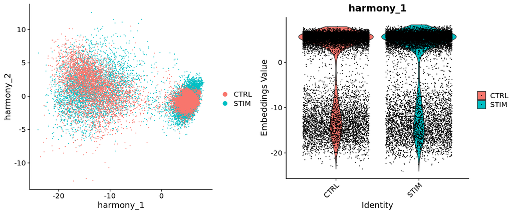

```r
# Let's make sure that the datasets are well integrated in the first 2 dimensions after Harmony.

options(repr.plot.height = 5, repr.plot.width = 12)
p1 <- DimPlot(object = pbmc, reduction = "harmony", pt.size = .1, group.by = "stim") # , do.return = TRUE
p2 <- VlnPlot(object = pbmc, features = "harmony_1", group.by = "stim", pt.size = .1) # , do.return = TRUE
plot_grid(p1,p2)
```

### Downstream analysis

To use the corrected Harmony embeddings rather than PCs, set `reduction = 'harmony'`.

For example, let's perform the UMAP and Nearest Neighbor analyses using the Harmony embeddings

```r
pbmc <- pbmc %>%
    RunUMAP(reduction = "harmony", dims = 1:20) %>%
    FindNeighbors(reduction = "harmony", dims = 1:20) %>%
    FindClusters(resolution = 0.5) %>%
    identity()
```

[output not shown]

[output cut: 31 more lines]

```
18:25:06 Searching Annoy index using 1 thread, search_k = 3000

18:25:18 Annoy recall = 100%

18:25:19 Commencing smooth kNN distance calibration using 1 thread

18:25:21 Initializing from normalized Laplacian + noise

18:25:23 Commencing optimization for 200 epochs, with 1152328 positive edges

18:25:42 Optimization finished

Computing nearest neighbor graph

Computing SNN
```

```
Modularity Optimizer version 1.3.0 by Ludo Waltman and Nees Jan van Eck

Number of nodes: 25894
Number of edges: 854543

Running Louvain algorithm...
Maximum modularity in 10 random starts: 0.9057
Number of communities: 14
Elapsed time: 6 seconds
```

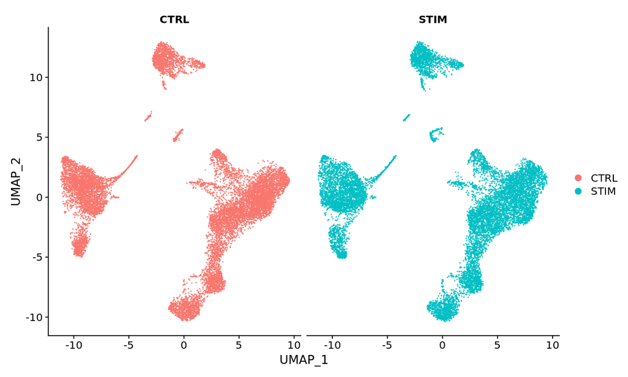

```r
# In the UMAP embedding, we can see more intricate structure. Since we used harmony embeddings, the UMAP embeddings are well mixed.

options(repr.plot.height = 6, repr.plot.width = 10)
DimPlot(pbmc, reduction = "umap", group.by = "stim", pt.size = .1, split.by = 'stim')
```

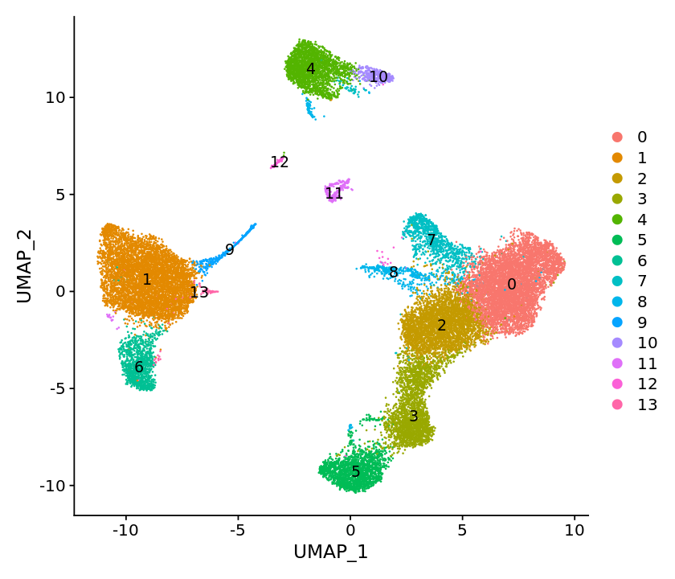

```r
# In this well mixed embedding, we can start identifying shared cell types with clustering analysis.

options(repr.plot.height = 6, repr.plot.width =7)
DimPlot(pbmc, reduction = "umap", label = TRUE, pt.size = .1)
```